# TP génération de nombres aléatoires et probabilités

# Question 2

## 2.1

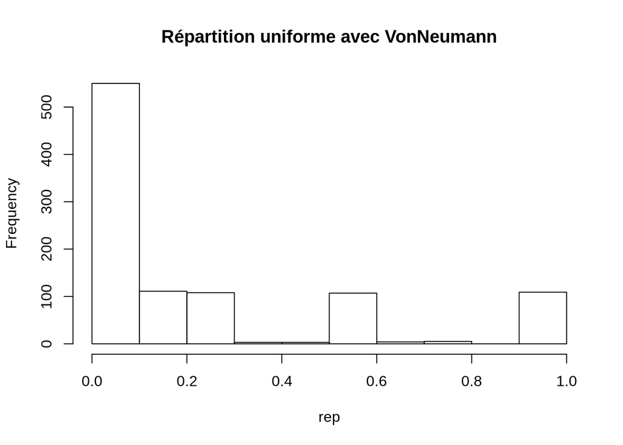

```r
breaks = 10
rep <- VonNeumann(k, 1, seed) / (9999)
hist(rep, main = "Répartition uniforme avec VonNeumann", breaks = breaks)
```

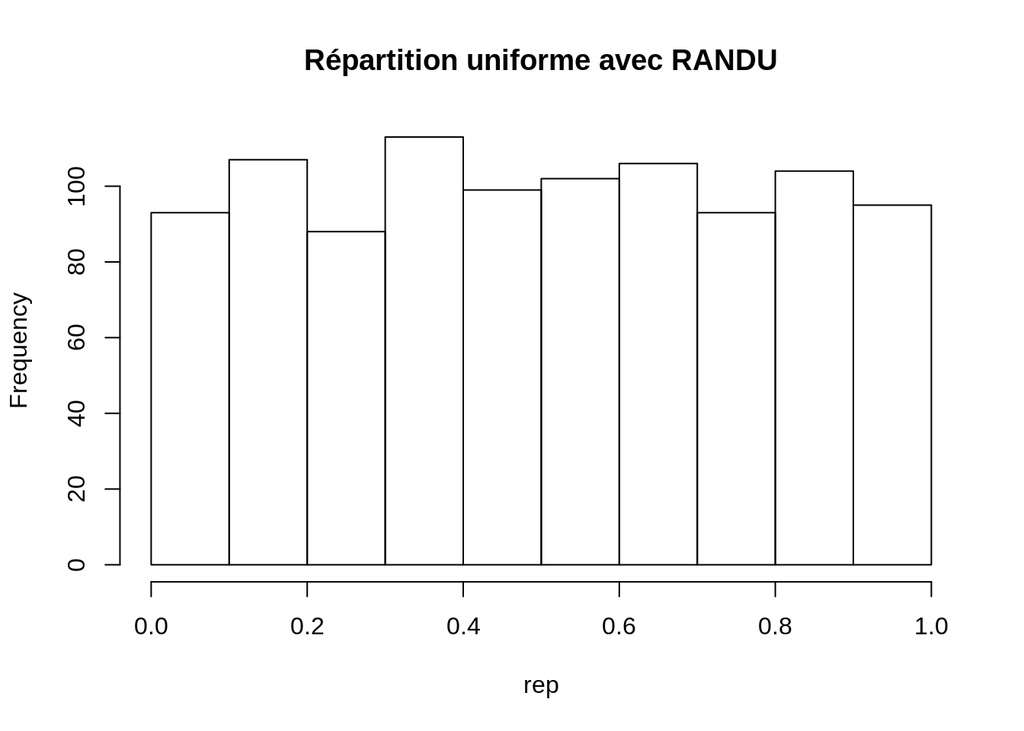

```r
rep <- randu(k, seed) / (2^31 - 1)
hist(rep, main = "Répartition uniforme avec RANDU", breaks = breaks)
```

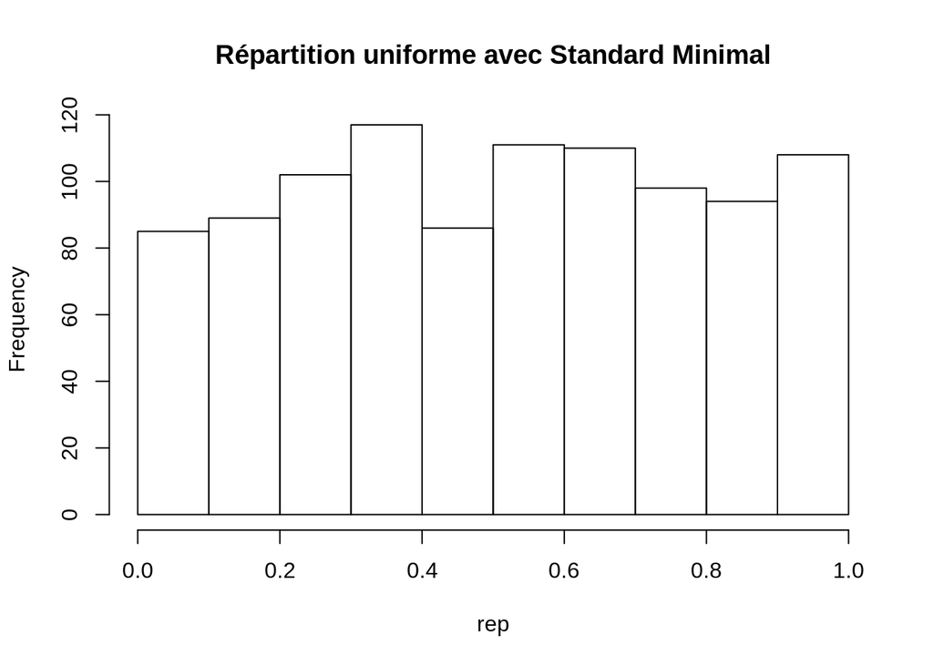

```r
rep <- std_minimal(k, seed) / (2^31 - 2)
hist(rep, main = "Répartition uniforme avec Standard Minimal", breaks = breaks)
```

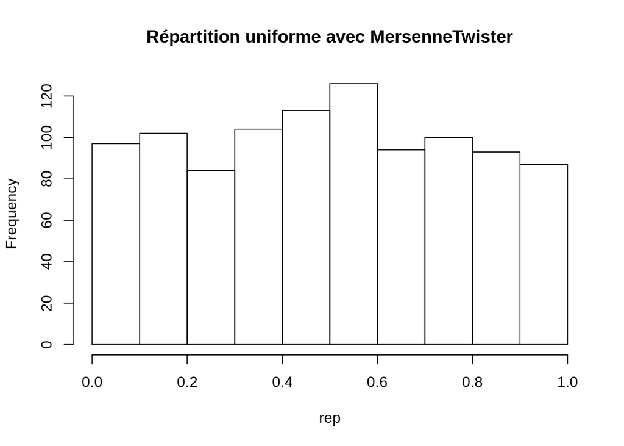

```r
rep <- MersenneTwister(k, 1, seed) / (2^32 - 1)
hist(rep, main = "Répartition uniforme avec MersenneTwister", breaks = breaks)
```

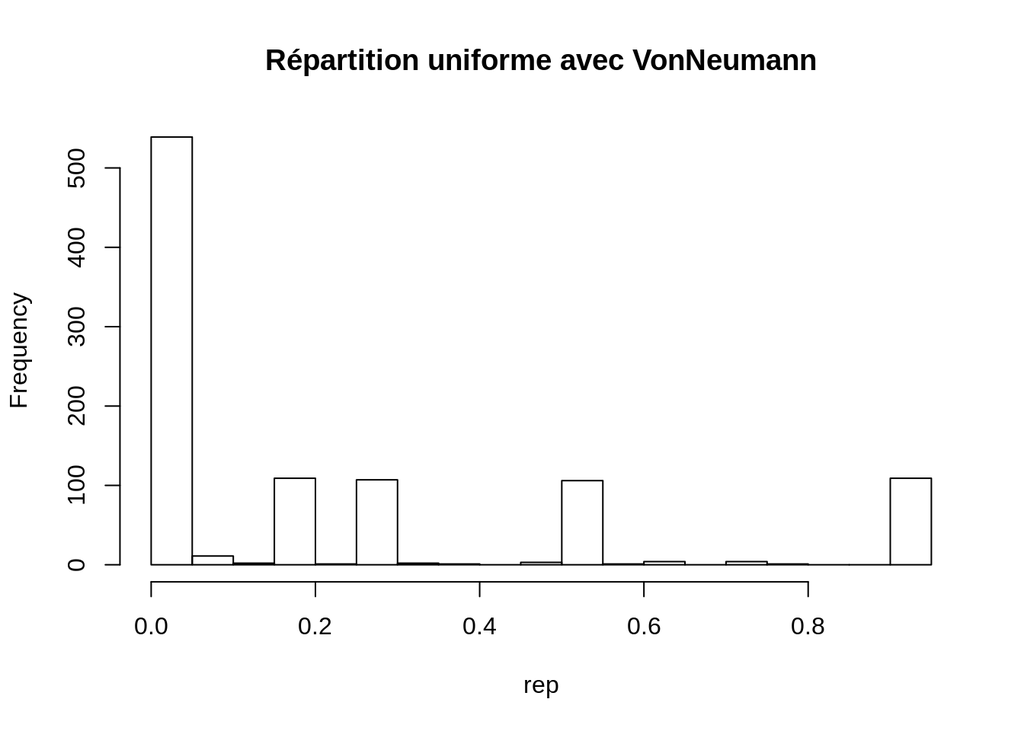

```r
breaks = 30
rep <- VonNeumann(k, 1, seed) / (9999)
hist(rep, main = "Répartition uniforme avec VonNeumann", breaks = breaks)
```

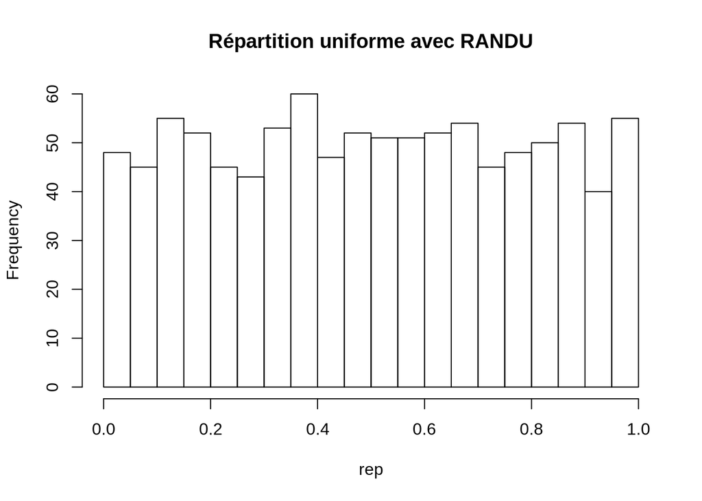

```r
rep <- randu(k, seed) / (2^31 - 1)
hist(rep, main = "Répartition uniforme avec RANDU", breaks = breaks)
```

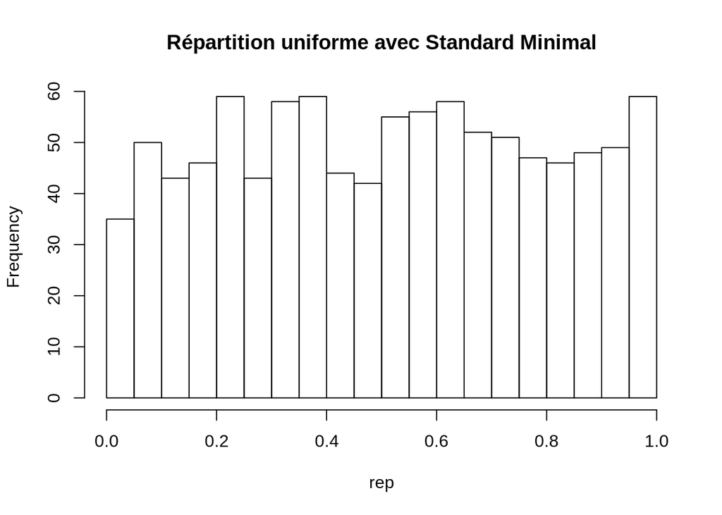

```r
rep <- std_minimal(k, seed) / (2^31 - 2)
hist(rep, main = "Répartition uniforme avec Standard Minimal", breaks = breaks)
```

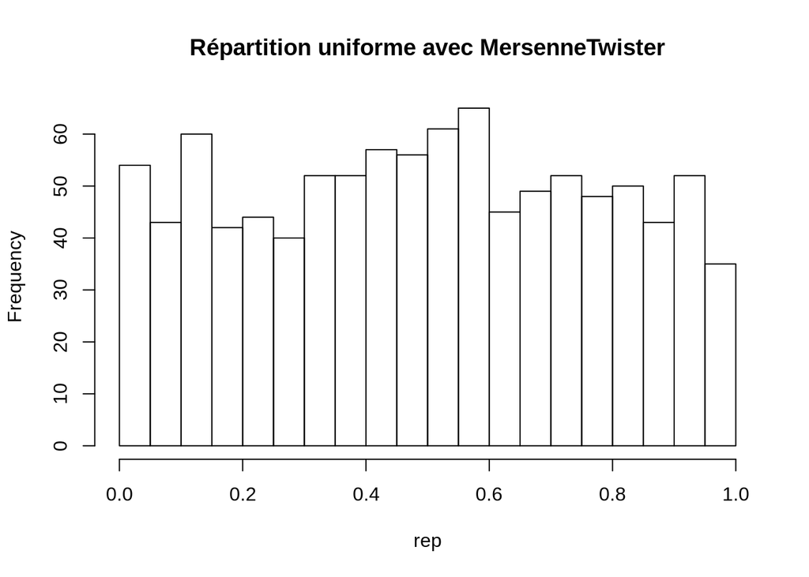

```r
rep <- MersenneTwister(k, 1, seed) / (2^32 - 1)
hist(rep, main = "Répartition uniforme avec MersenneTwister", breaks = breaks)
```

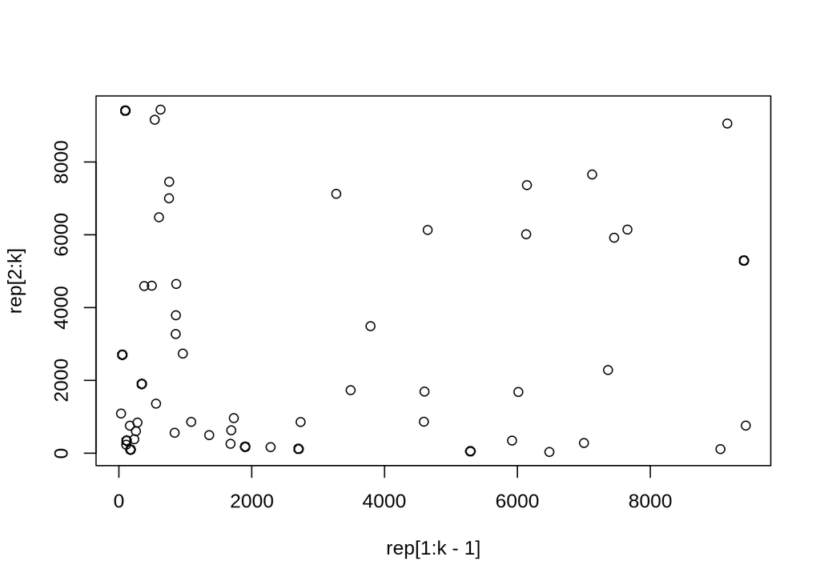

```r
rep <- VonNeumann(k, 1, seed)
plot(rep[1:k-1], rep[2:k])
```

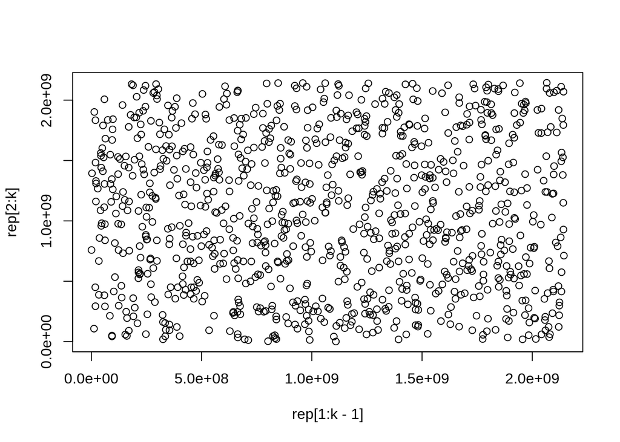

```r
rep <- randu(k, seed)
plot(rep[1:k-1], rep[2:k])
```

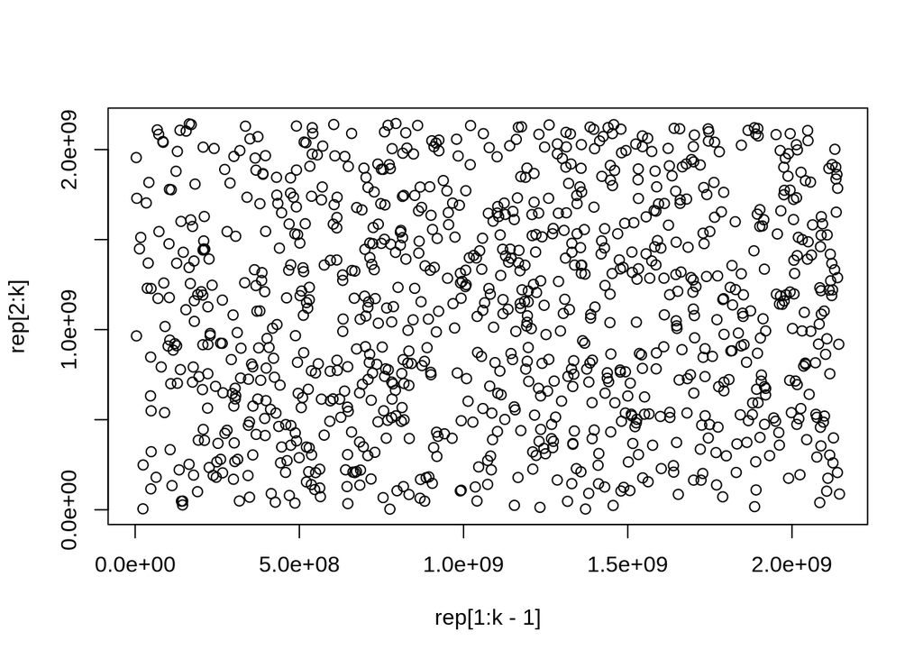

```r
rep <- std_minimal(k, seed)
plot(rep[1:k-1], rep[2:k])
```

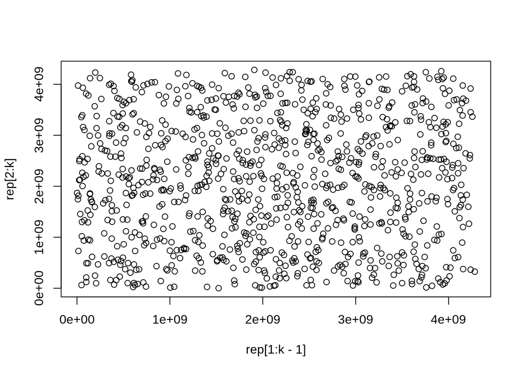

```r
rep <- MersenneTwister(k, 1, seed)
plot(rep[1:k-1], rep[2:k])
```

# Question 3

Pour VonNeumann et RANDU, on observe pour la plupart des tests que la p valeur est en dessous des 1 %.

Pour Standard Minimal et MersenneTwister, on observe très peu de p valeurs inférieures à 1 %.

Ainsi, RANDU et VonNeumann ne passe le premier test et n’est donc pas un bon générateur aléatoire.

Pour Standard Minimal et MersenneTwister, on ne peut rien conclure pour l’instant.

```r
nb_seed <- 100
seed <- sample.int(2^31, nb_seed)
ShowTestResults <- function(frequence)
{
  nb_reussis <- PercentageTest(frequence, 0.01)
  percentage <- nb_reussis / nb_seed
  plot(frequence, xlim = c(0, 100), ylim = c(0, 1.0))
  abline(h = 0.01, col = "red")
  mtext(paste("Proportion de tests réussis : ", percentage * 100, " %"), side = 3)
  pie(c(percentage, 1 - percentage), labels = c(nb_reussis, nb_seed - nb_reussis), col = c("green", "red"))
  legend("topright", c(">= 0.01", "< 0.01"), cex = 0.8, fill = c("green", "red"))
}
```

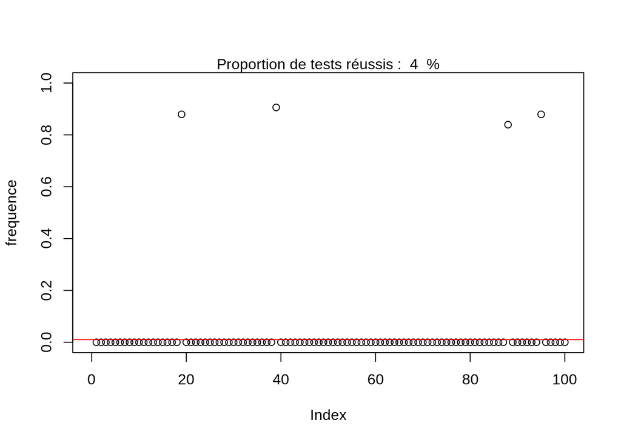

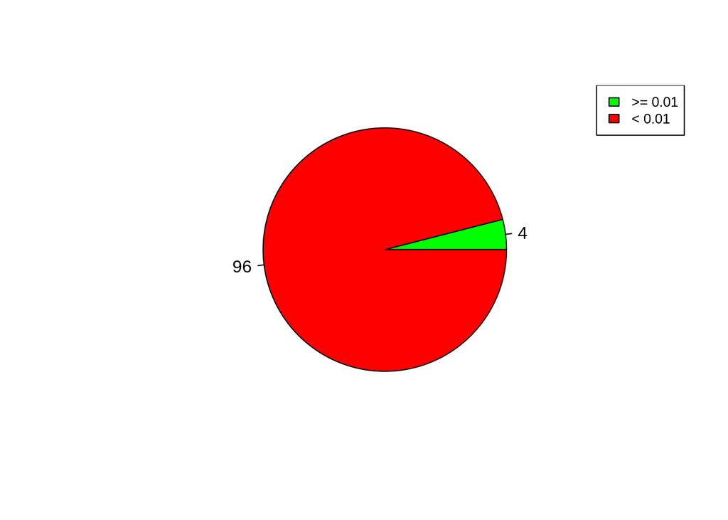

```r
frequence <- sapply(seed, function(s) Frequency(VonNeumann(k, 1, s), 14))
ShowTestResults(frequence)
```

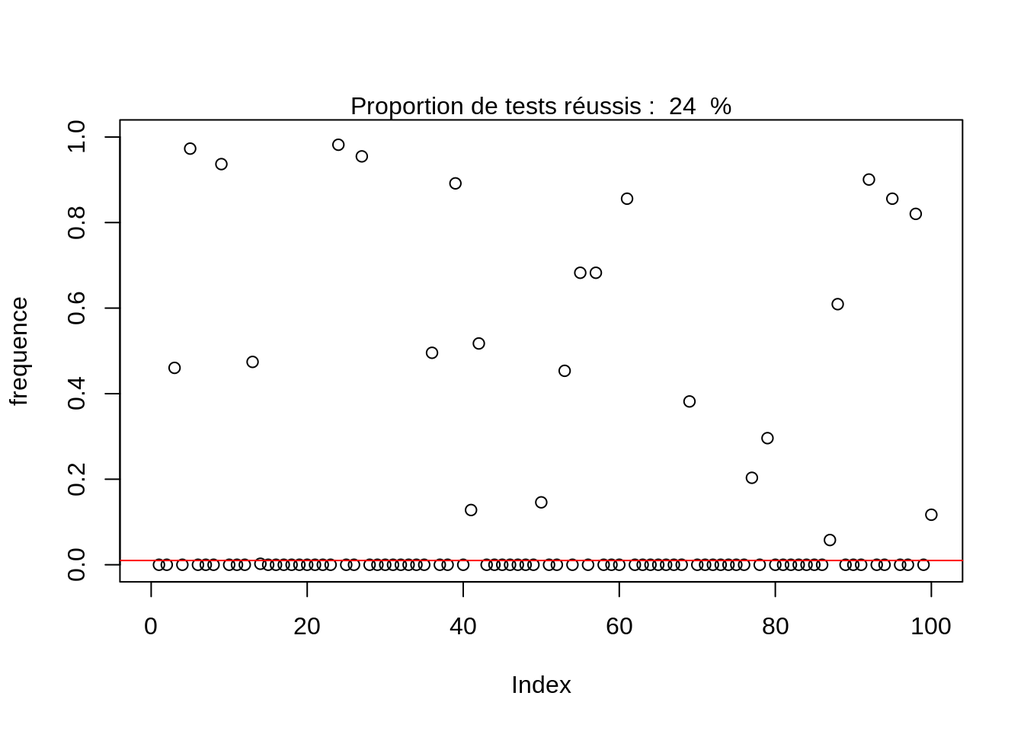

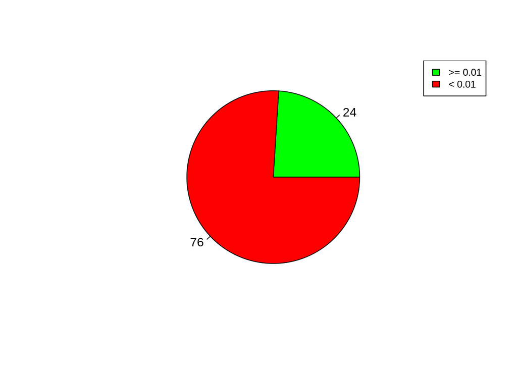

```r
frequence <- sapply(seed, function(s) Frequency(randu(k, s), 31))
ShowTestResults(frequence)
```

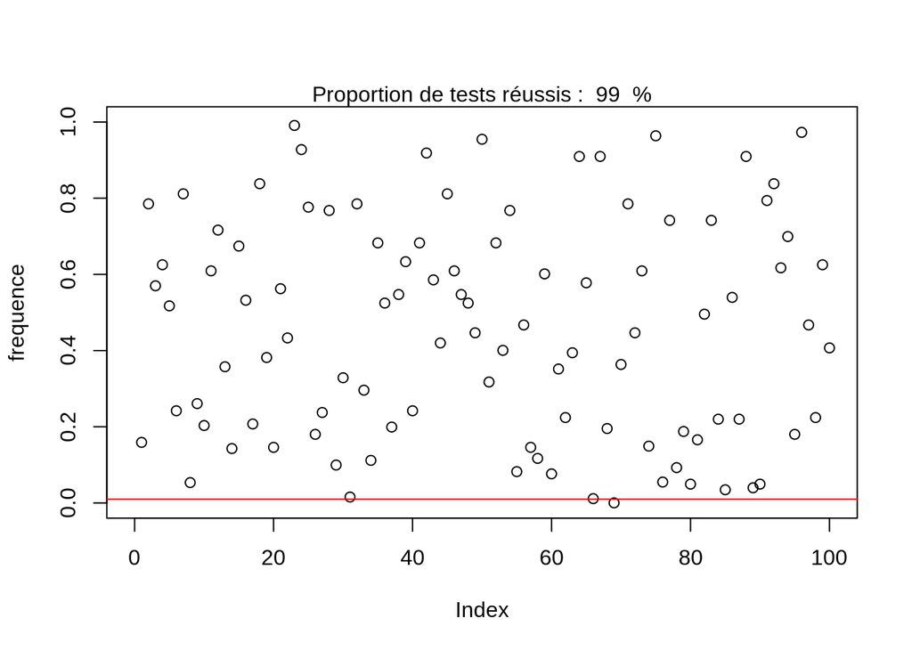

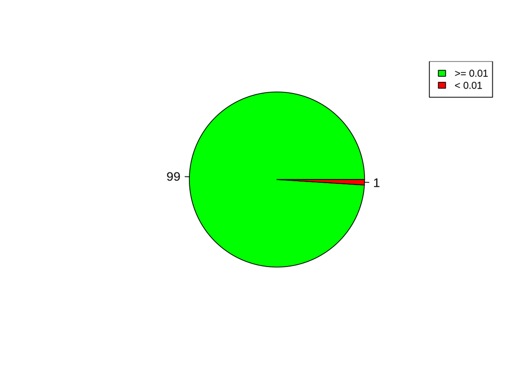

```r
frequence <- sapply(seed, function(s) Frequency(std_minimal(k, s), 31))
ShowTestResults(frequence)
```

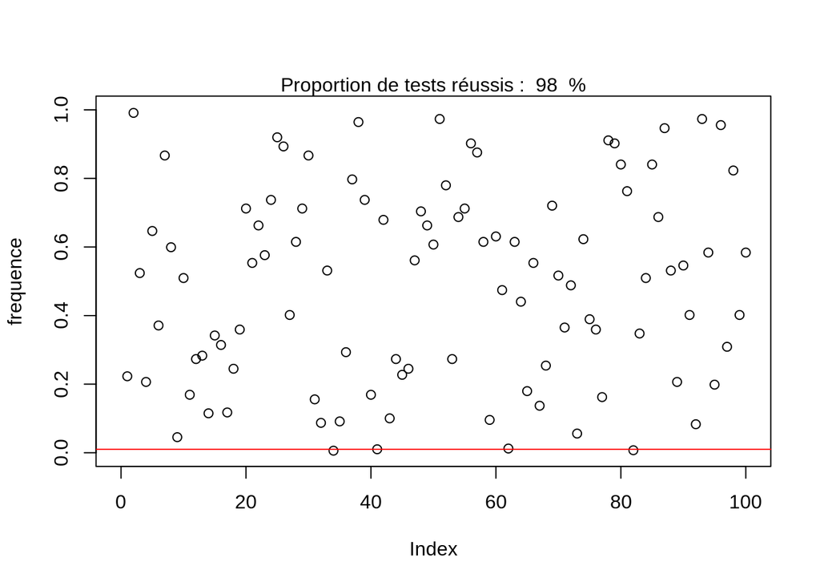

```r
frequence <- sapply(seed, function(s) Frequency(MersenneTwister(k, 1, s), 32))
ShowTestResults(frequence)
```

[output not shown]

# Question 4

Pour VonNeumann et RANDU, on observe pour la plupart des tests que la p valeur est en dessous des 1 %.

Pour Standard Minimal et MersenneTwister, on observe très peu de p valeurs inférieures à 1 %.

Pour Standard Minimal et MersenneTwister, on ne peut rien conclure pour l’instant.

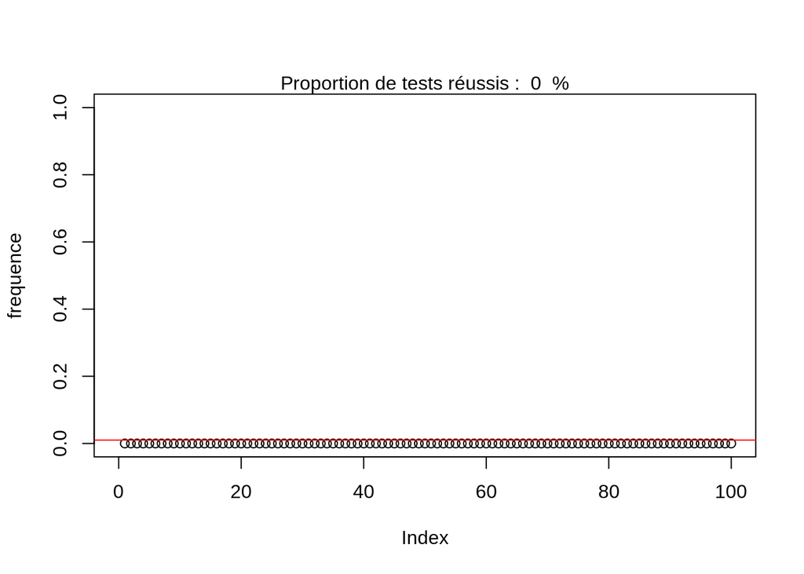

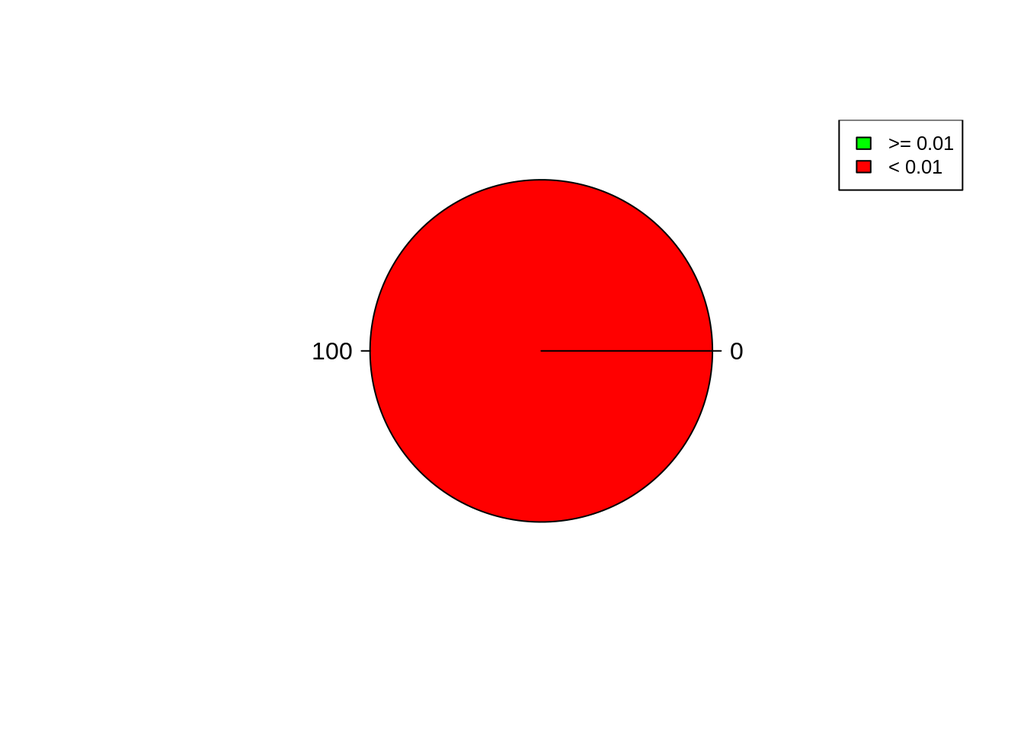

```r
frequence <- sapply(seed, function(s) Runs(VonNeumann(k, 1, s), 14))
ShowTestResults(frequence)
```

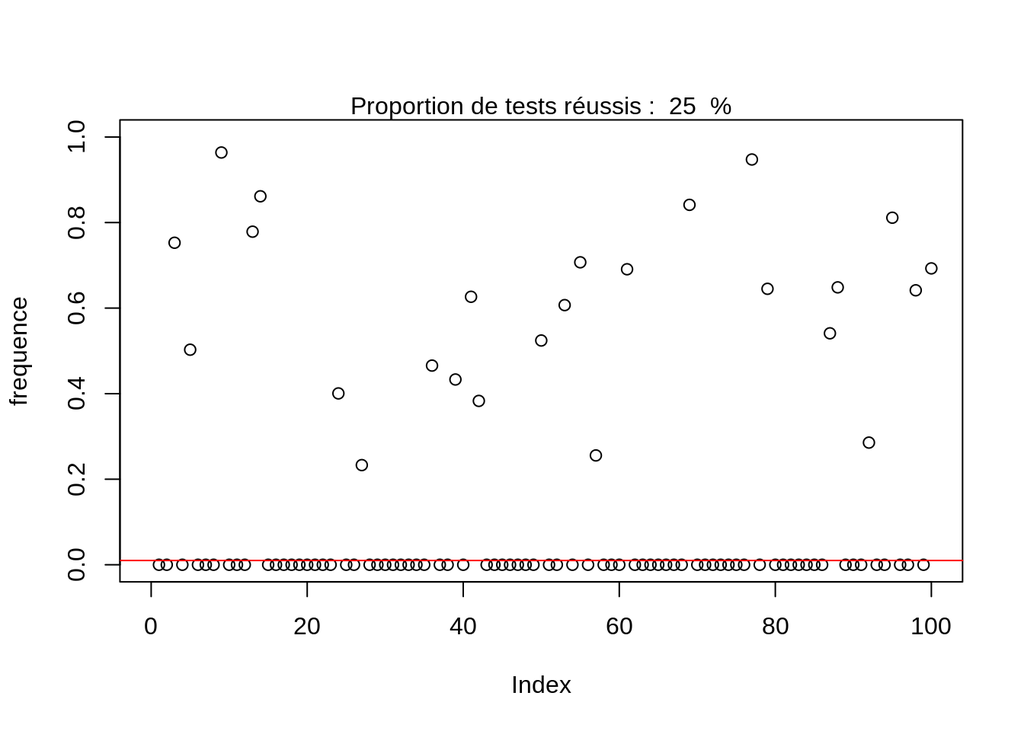

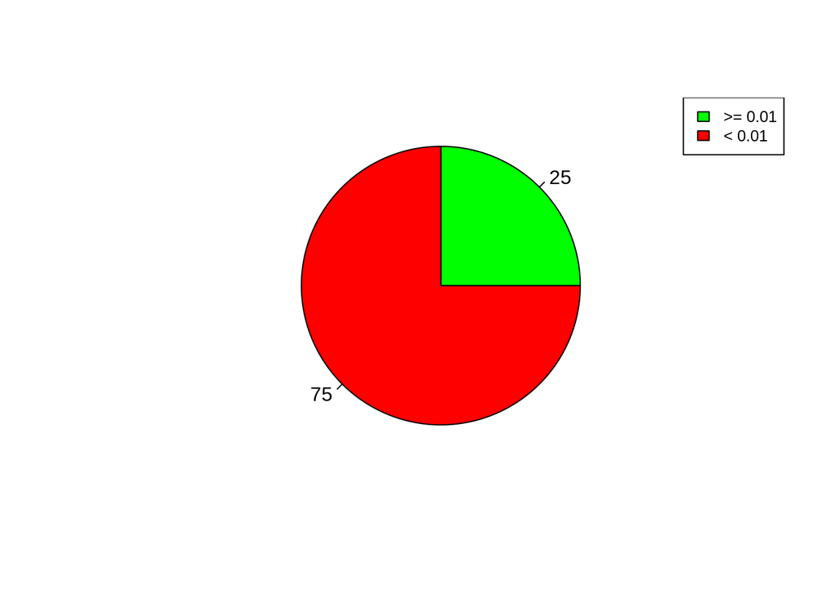

```r
frequence <- sapply(seed, function(s) Runs(randu(k, s), 31))
ShowTestResults(frequence)
```

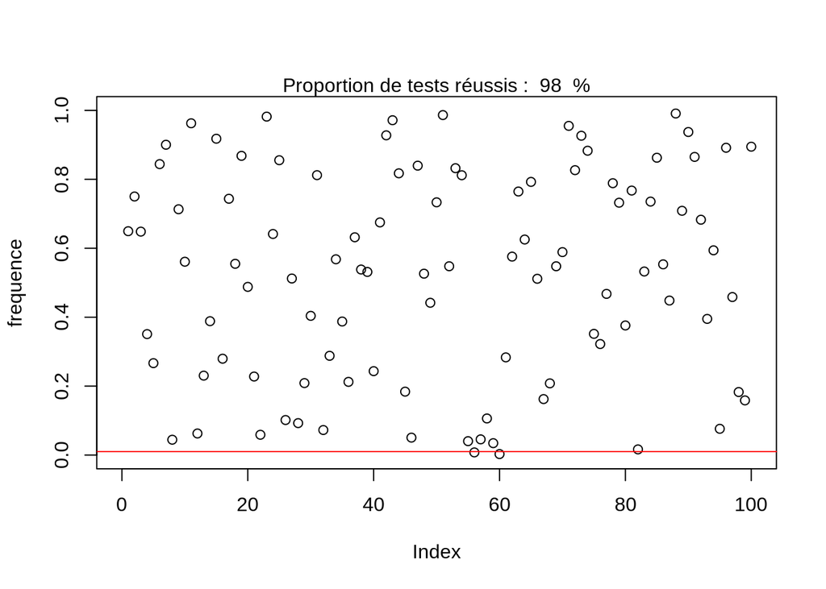

```r
frequence <- sapply(seed, function(s) Runs(std_minimal(k, s), 31))
ShowTestResults(frequence)
```

[output not shown]

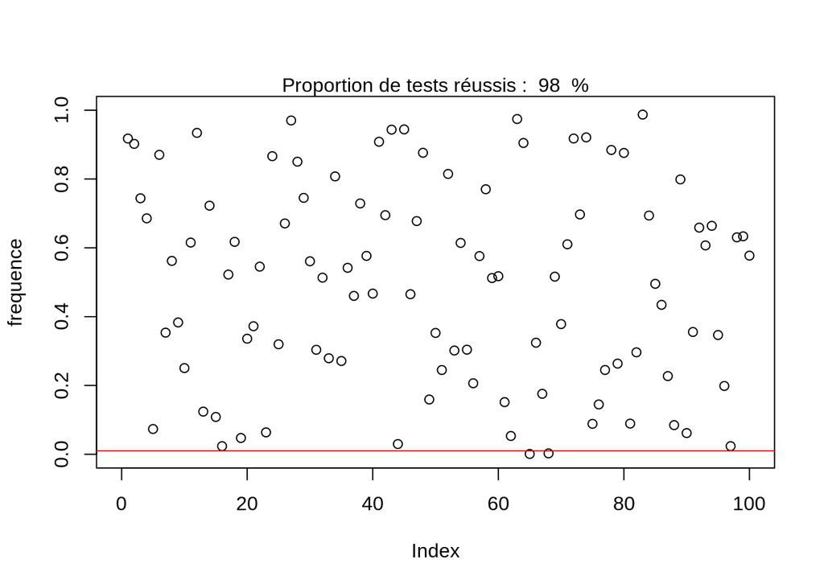

```r
frequence <- sapply(seed, function(s) Runs(MersenneTwister(k, 1, s), 32))
ShowTestResults(frequence)
```

[output not shown]

# Question 5

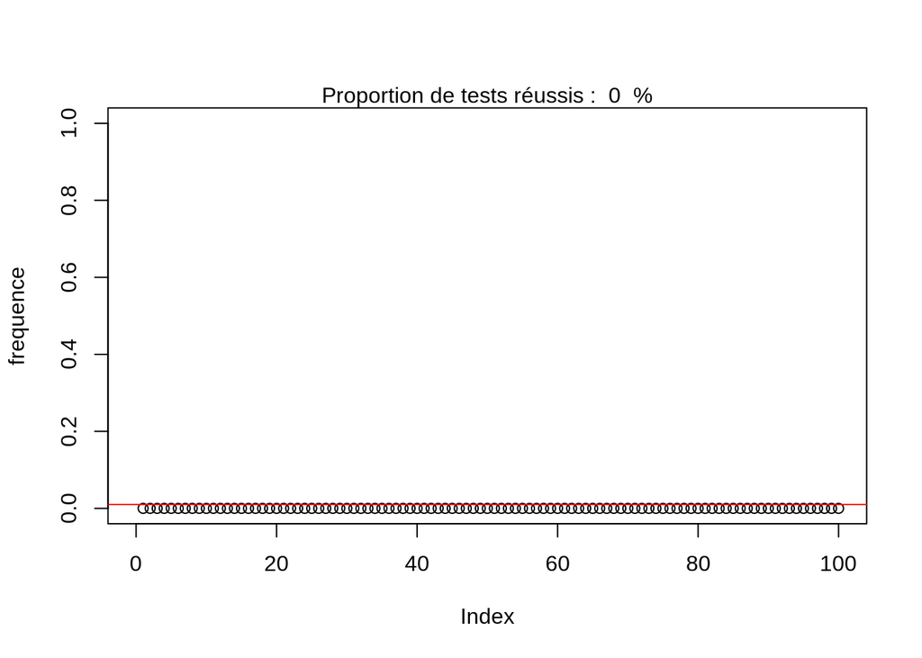

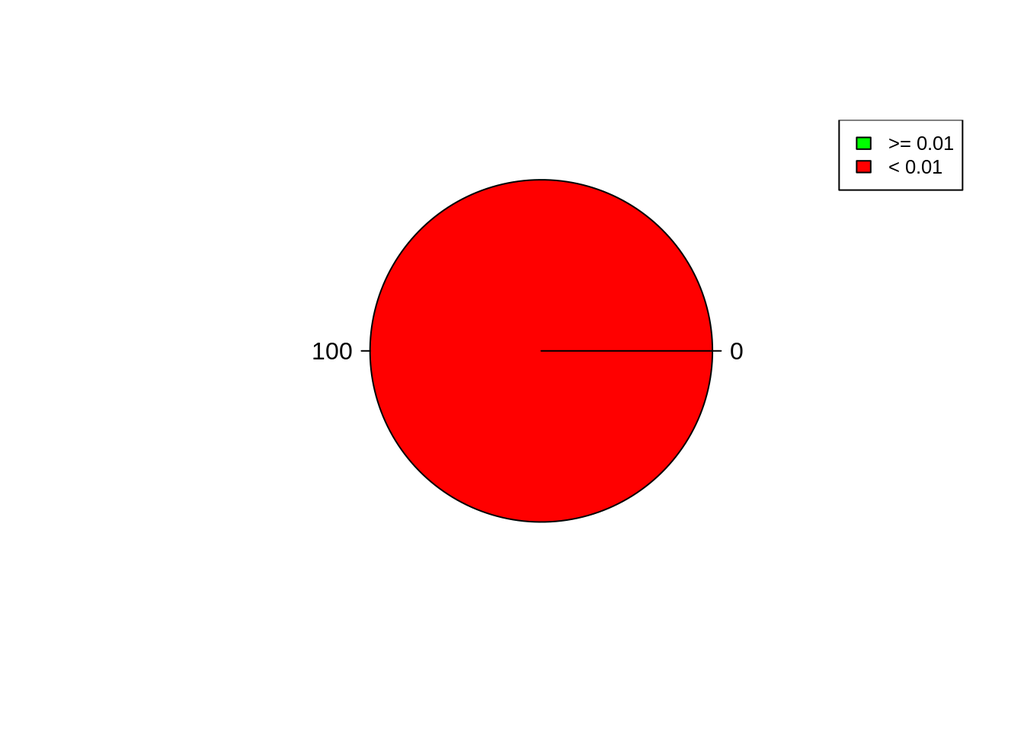

```r
frequence <- sapply(seed, function(s) order.test(as.vector(VonNeumann(k, 1, s)), d = 4, echo=FALSE)$p.value)
ShowTestResults(frequence)
```

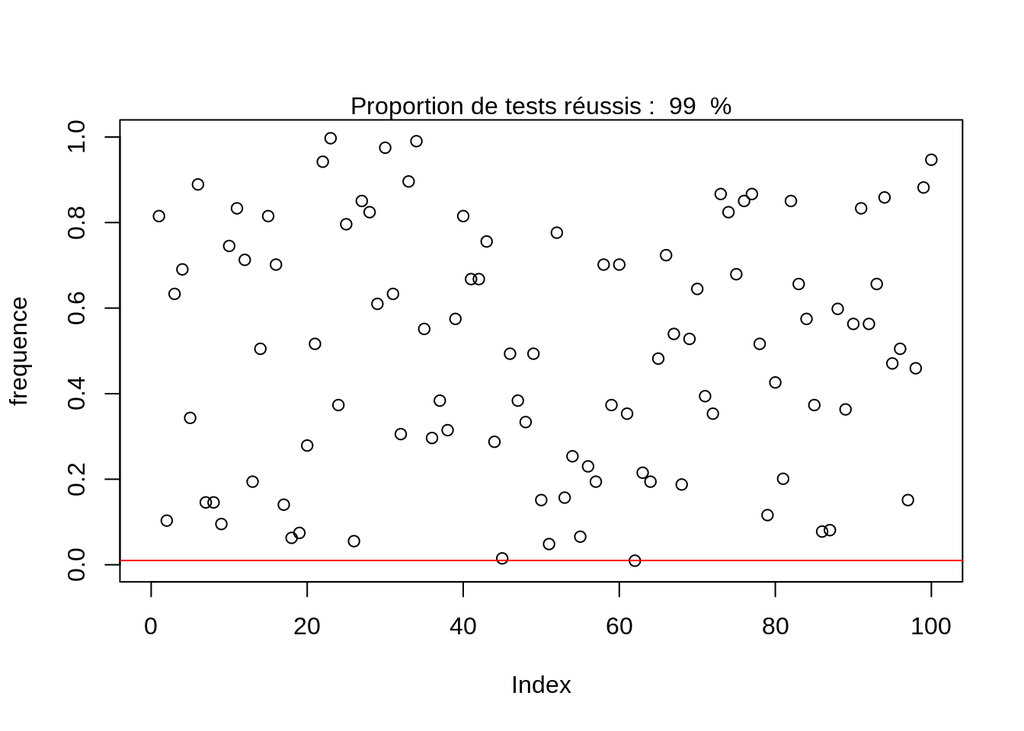

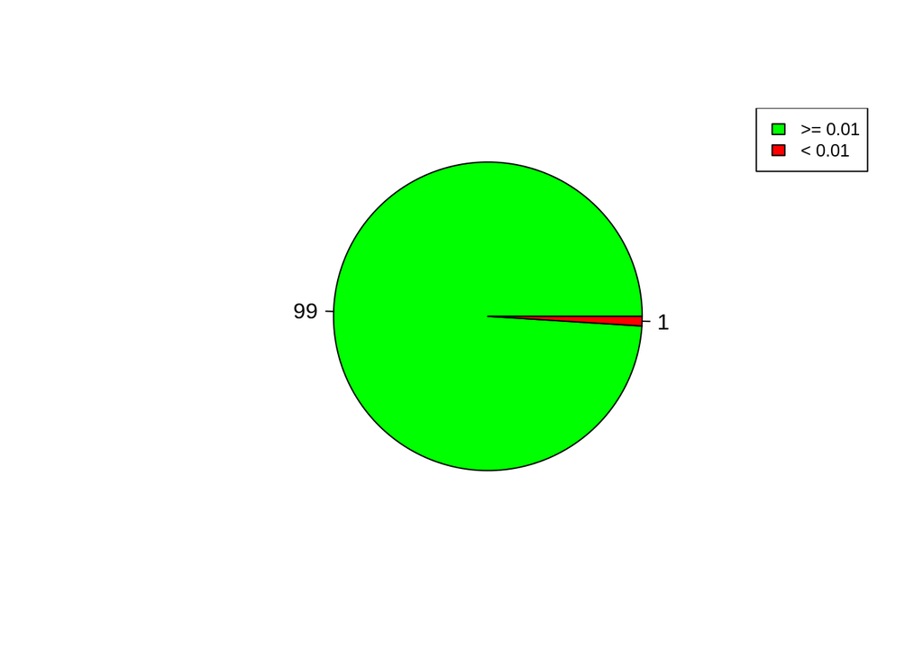

```r
frequence <- sapply(seed, function(s) order.test(randu(k, s), d = 4, echo=FALSE)$p.value)
ShowTestResults(frequence)
```